# ass3

XU Ke_3035809704

2020/12/6

```r
rm(list = ls())
```

# Q1

```r
rm(list=ls())
```

```r
cancer <- read.table('lungcancer.txt')
tcancer <- t(cancer)
datacancer0 <- data.frame(tcancer)
```

Divide the data into four kinds: Carcinoid, Colon, Normal, SmallCell.

```r
category <- data.frame('category' = c(1:56))
for (i in 1:20){
  category[,'category'][i] <- 'Carcinoid'
}
for (i in 21:33){
  category[,'category'][i] <- 'Colon'
}
for (i in 34:50){
  category[,'category'][i] <- 'Normal'
}
for (i in 51:56){
  category[,'category'][i] <- 'SmallCell'
}
datacancer1 <- cbind(category, datacancer0)
```

## Q1.1

### Q1.1.1

center the data

```r
pca1 <- prcomp(datacancer1[, -1], canter = TRUE)
summary(pca1)
```

```
## Importance of components:
##                            PC1     PC2      PC3     PC4     PC5     PC6     PC7
## Standard deviation     27.8423 16.8233 11.94556 9.51989 8.94714 8.16457 7.66571
## Proportion of Variance  0.3565  0.1302  0.06563 0.04168 0.03682 0.03066 0.02703
## Cumulative Proportion   0.3565  0.4867  0.55231 0.59399 0.63081 0.66147 0.68849
##                           PC8     PC9    PC10    PC11    PC12    PC13    PC14
## Standard deviation     7.2545 6.36183 5.72524 5.58761 5.29106 5.23950 5.11626
## Proportion of Variance 0.0242 0.01861 0.01508 0.01436 0.01288 0.01263 0.01204
## Cumulative Proportion  0.7127 0.73131 0.74639 0.76074 0.77362 0.78625 0.79828
##                           PC15    PC16    PC17    PC18   PC19    PC20    PC21
## Standard deviation     4.86629 4.64629 4.48987 4.36599 4.2473 4.20029 4.04614
## Proportion of Variance 0.01089 0.00993 0.00927 0.00877 0.0083 0.00811 0.00753
## Cumulative Proportion  0.80918 0.81910 0.82838 0.83714 0.8454 0.85355 0.86108
##                           PC22    PC23    PC24    PC25    PC26    PC27    PC28
## Standard deviation     4.03054 3.86024 3.82144 3.77750 3.55304 3.49641 3.46044
## Proportion of Variance 0.00747 0.00685 0.00672 0.00656 0.00581 0.00562 0.00551
## Cumulative Proportion  0.86855 0.87541 0.88212 0.88869 0.89449 0.90011 0.90562
##                           PC29    PC30    PC31    PC32    PC33   PC34    PC35
## Standard deviation     3.44678 3.37805 3.33714 3.26713 3.23419 3.1614 3.11112
## Proportion of Variance 0.00546 0.00525 0.00512 0.00491 0.00481 0.0046 0.00445
## Cumulative Proportion  0.91108 0.91633 0.92145 0.92636 0.93117 0.9358 0.94022
##                           PC36    PC37    PC38    PC39    PC40   PC41    PC42
## Standard deviation     3.08035 3.00322 2.92175 2.88039 2.84936 2.7991 2.74261
## Proportion of Variance 0.00436 0.00415 0.00393 0.00382 0.00373 0.0036 0.00346
## Cumulative Proportion  0.94459 0.94873 0.95266 0.95648 0.96021 0.9638 0.96727
##                           PC43    PC44    PC45    PC46    PC47    PC48    PC49
## Standard deviation     2.70041 2.67321 2.61353 2.48543 2.46023 2.40185 2.29755
## Proportion of Variance 0.00335 0.00329 0.00314 0.00284 0.00278 0.00265 0.00243
## Cumulative Proportion  0.97063 0.97391 0.97705 0.97990 0.98268 0.98533 0.98776
##                          PC50    PC51   PC52    PC53    PC54    PC55      PC56
## Standard deviation     2.2853 2.22991 2.1883 2.14831 1.88657 1.85871 1.607e-14
## Proportion of Variance 0.0024 0.00229 0.0022 0.00212 0.00164 0.00159 0.000e+00
## Cumulative Proportion  0.9902 0.99245 0.9947 0.99677 0.99841 1.00000 1.000e+00
```

```r
pve = (pca1$sdev^2)/sum(pca1$sdev^2)
pve
```

```
##  [1] 3.565187e-01 1.301654e-01 6.562755e-02 4.168089e-02 3.681645e-02
##  [6] 3.065774e-02 2.702573e-02 2.420402e-02 1.861388e-02 1.507511e-02
## [11] 1.435902e-02 1.287533e-02 1.262563e-02 1.203869e-02 1.089105e-02
## [16] 9.928571e-03 9.271321e-03 8.766771e-03 8.296748e-03 8.113956e-03
## [21] 7.529315e-03 7.471375e-03 6.853336e-03 6.716249e-03 6.562697e-03
## [26] 5.805953e-03 5.622350e-03 5.507278e-03 5.463868e-03 5.248150e-03
## [31] 5.121783e-03 4.909152e-03 4.810664e-03 4.596418e-03 4.451504e-03
## [36] 4.363883e-03 4.148087e-03 3.926071e-03 3.815710e-03 3.733946e-03
## [41] 3.603350e-03 3.459400e-03 3.353765e-03 3.286549e-03 3.141440e-03
## [46] 2.841031e-03 2.783718e-03 2.653170e-03 2.427755e-03 2.402018e-03
## [51] 2.286894e-03 2.202265e-03 2.122585e-03 1.636880e-03 1.588898e-03
## [56] 1.188014e-31
```

### Q1.1.2

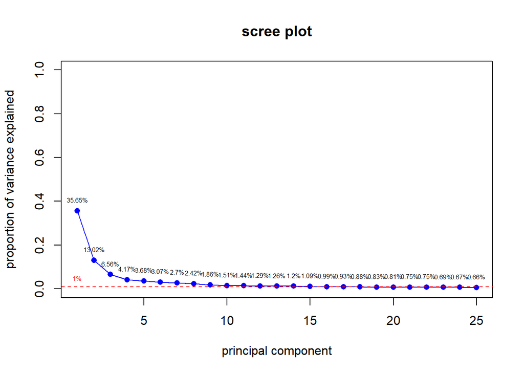

```r
plot(pve[1:25],
     xlab = 'principal component',
     ylab = 'proportion of variance explained',
     main = 'scree plot',
     ylim = c(0,1),
     type = 'o',
     col ='blue',
     pch = 16)
for (i in 1:25){
       text(i, pve[i]+0.05, cex = 0.5, paste0(round(pve[i]*100, 2),'%'))
}
abline(h  = 0.01, col = 'red', lty =2)
text(1, 0.05, '1%', cex = 0.5, col = 'red')
```

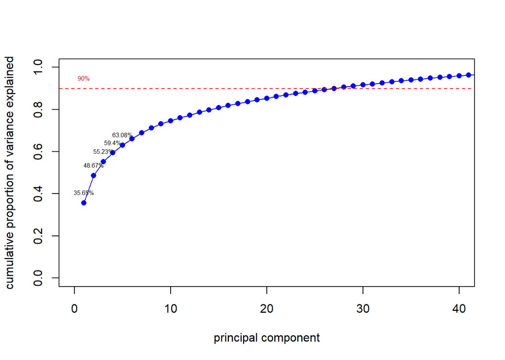

```r
plot(cumsum(pve),
     xlab = 'principal component',
     ylab = 'cumulative proportion of variance explained',
     xlim = c(0,40),
     ylim = c(0,1),
     type = 'o',
     col ='blue',
     pch = 16)
for (i in 1:5){
       text(i, cumsum(pve)[i]+0.05, cex = 0.5, paste0(round(cumsum(pve)[i]*100, 2),'%'))
}
abline(h = 0.9, lty = 2,col = 'red')
text(1, 0.95, cex = 0.5, '90%', col = 'red')
```

```r
cumsum(pve)
```

```
##  [1] 0.3565187 0.4866840 0.5523116 0.5939925 0.6308089 0.6614667 0.6884924
##  [8] 0.7126964 0.7313103 0.7463854 0.7607444 0.7736198 0.7862454 0.7982841
## [15] 0.8091751 0.8191037 0.8283750 0.8371418 0.8454385 0.8535525 0.8610818
## [22] 0.8685532 0.8754065 0.8821228 0.8886855 0.8944914 0.9001138 0.9056210
## [29] 0.9110849 0.9163331 0.9214548 0.9263640 0.9311747 0.9357711 0.9402226
## [36] 0.9445865 0.9487346 0.9526606 0.9564763 0.9602103 0.9638136 0.9672730
## [43] 0.9706268 0.9739133 0.9770548 0.9798958 0.9826795 0.9853327 0.9877605
## [50] 0.9901625 0.9924494 0.9946516 0.9967742 0.9984111 1.0000000 1.0000000
```

The growth of variance explained by principal components starts to be slow after the 3rd principal component, so 3 PCs are sufficient.

### Q1.1.3

```r
pcscore <- data.frame(category = datacancer1$category, pca1$x)
pcscore$category <- as.factor(pcscore$category)
group <- NA
group[pcscore$category=="Carcinoid"] <- 1
group[pcscore$category=="Colon"] <- 2
group[pcscore$category=="Normal"] <- 3
group[pcscore$category=="SmallCell"] <- 4
```

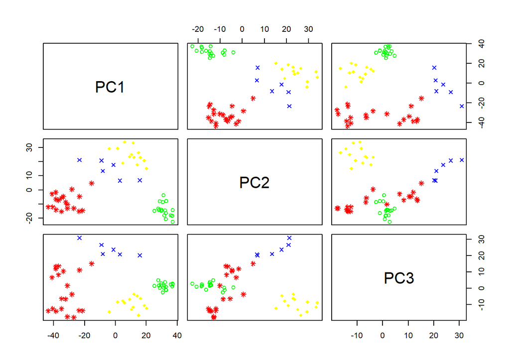

```r
pairs(pcscore[,c(2,3,4)], col=c('red', 'yellow','green','blue')[group],pch = c(8,18,1,4)[group])
```

```r
library(ggplot2)
```

plot of PC1 and PC2

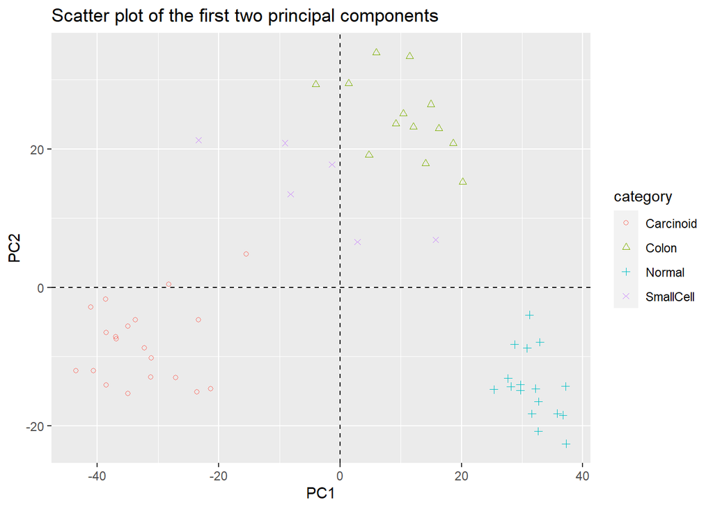

```r
p.pcscore <- ggplot(data=pcscore,aes(x=PC1,y=PC2,color=category,shape = category)) +
  geom_point() +
  scale_shape_manual(values=1:7)  +
  geom_hline(yintercept=0, linetype="dashed", color = "black") +
  geom_vline(xintercept=0, linetype="dashed", color = "black")

p.pcscore + labs(title="Scatter plot of the first two principal components")
```

plot of PC1 and PC3

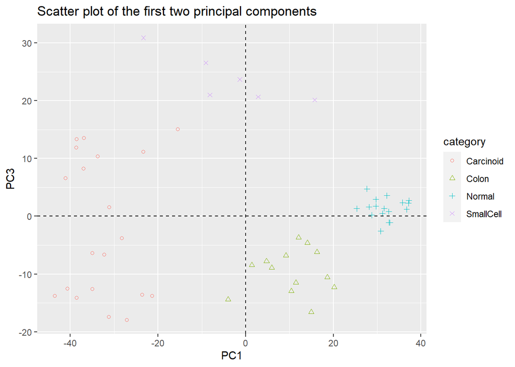

```r
p.pcscore2 <- ggplot(data=pcscore,aes(x=PC1,y=PC3,color=category,shape = category)) +
  geom_point() +
  scale_shape_manual(values=1:7)  +
  geom_hline(yintercept=0, linetype="dashed", color = "black") +
  geom_vline(xintercept=0, linetype="dashed", color = "black")

p.pcscore2 + labs(title="Scatter plot of the first two principal components")
```

plot of PC2 and PC3

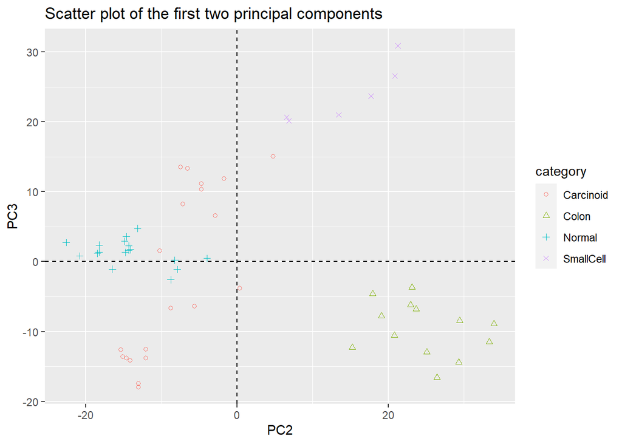

```r
p.pcscore3 <- ggplot(data=pcscore,aes(x=PC2,y=PC3,color=category,shape = category)) +
  geom_point() +
  scale_shape_manual(values=1:7)  +
  geom_hline(yintercept=0, linetype="dashed", color = "black") +
  geom_vline(xintercept=0, linetype="dashed", color = "black")

p.pcscore3 + labs(title="Scatter plot of the first two principal components")
```

PC1 and PC2, PC1 and PC3 can separate each category well, PC2 and PC3 cannot separate Carcinoid and Normal.

## 1.2

```r
# Help function
multiplot <- function(..., plotlist=NULL, file, cols=1, layout=NULL) {
  #library(grid)

  # Make a list from the ... arguments and plotlist
  plots <- c(list(...), plotlist)

  numPlots = length(plots)

  # If layout is NULL, then use 'cols' to determine layout
  if (is.null(layout)) {
    # Make the panel
    # ncol: Number of columns of plots
    # nrow: Number of rows needed, calculated from # of cols
    layout <- matrix(seq(1, cols * ceiling(numPlots/cols)),
                    ncol = cols, nrow = ceiling(numPlots/cols))
  }

 if (numPlots==1) {
    print(plots[[1]])
  } else {
    # Set up the page
    grid.newpage()
    pushViewport(viewport(layout = grid.layout(nrow(layout), ncol(layout))))

    # Make each plot, in the correct location
    for (i in 1:numPlots) {
      # Get the i,j matrix positions of the regions that contain this subplot
      matchidx <- as.data.frame(which(layout == i, arr.ind = TRUE))

      print(plots[[i]], vp = viewport(layout.pos.row = matchidx$row,
                                      layout.pos.col = matchidx$col))
    }
  }
}

Clusterplot <- function(data0,n.pc,n.cluster,method='K-Means', scale=TRUE, outliers = TRUE){
  if (n.pc < 2){return ('Number of PC should be >= 2')}

  # Use first n.pc Principal Components to do analysis
  data = data0[,1:n.pc]


  if (scale==TRUE){
    # Center the mean to 0 and set the sd to 1
    data = scale(data,center=TRUE,scale = TRUE)
    }

  if (method == 'K-Means'){
    # Use K-Means model to do clustering
    set.seed(7002)
    km <- kmeans(data, n.cluster, iter.max = 1000, nstart = 10)
    pred <- as.character(km$cluster)}
  if (method == 'Hierarchical Clustering'){
    # Use Hierarchical Clustering to do clustering
    dist_mat <- dist(data[,1:n.pc], method = 'euclidean')
    hclust_avg <- hclust(dist_mat, method = 'average')
    pred <- as.character(cutree(hclust_avg, k = n.cluster))
  }

  if (outliers == TRUE){
    postfix = 'with Outliers'}else{
      postfix = 'without Outliers'
    }

    p <-ggplot(data=data.frame(Cluster=pred,data0),aes(x=PC1,y=PC2,color=Cluster,shape = Cluster)) +
    geom_point() +
  scale_shape_manual(values=1:7) +
  labs(title=paste0(method,' With K =',n.cluster),
       subtitle = paste("First",n.pc,"PC's Used",postfix)) +
  geom_hline(yintercept=0, linetype="dashed", color = "black") +
  geom_vline(xintercept=0, linetype="dashed", color = "black")
  return (p)
}
```

K-means clustering

```r
library(grid)
```

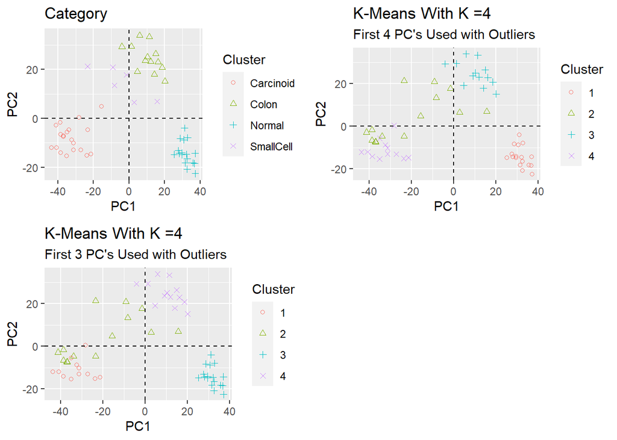

```r
pic1 <- Clusterplot(pcscore[,-c(1)],3,4,'K-Means')
pic2 <- Clusterplot(pcscore[,-c(1)],4,4,'K-Means')
multiplot(p.pcscore + labs(title="Category" ,color = "Cluster", shape='Cluster') +
            geom_hline(yintercept=0, linetype="dashed", color = "black") +
            geom_vline(xintercept=0, linetype="dashed", color = "black"),
          pic1,pic2, cols=2)
```

There is no difference between the picture of 3 PCs and 4PCs, so 3 PCs are sufficient.

Hierarchical clustering

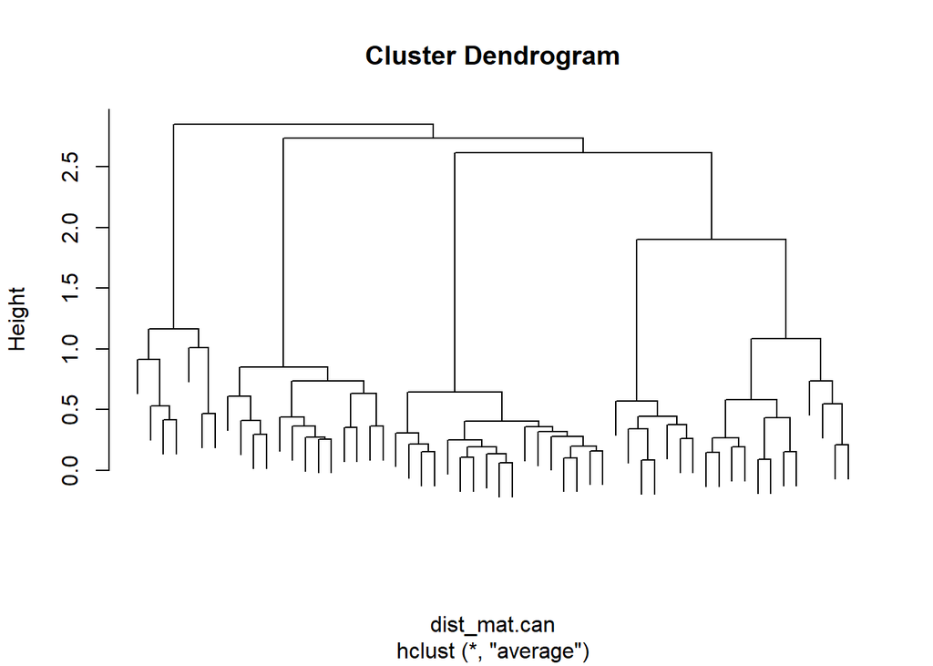

```r
pcscore.2 <- scale(pcscore[,c('PC1','PC2','PC3')],center=TRUE,scale = TRUE)
dist_mat.can <- dist(pcscore.2, method = 'euclidean')
hclust_avg.can <- hclust(dist_mat.can, method = 'average')
plot(hclust_avg.can,labels=FALSE)
```

```r
library(dendextend)
```

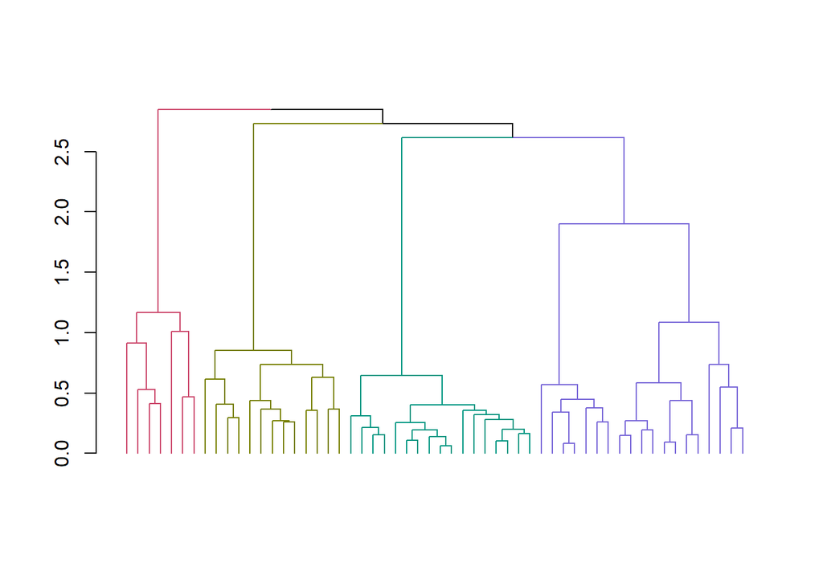

```r
avg_dend_obj.can <- as.dendrogram(hclust_avg.can)
avg_col_dend.can <- color_branches(avg_dend_obj.can, k = 4)
labels_colors(avg_col_dend.can) <- "white"
plot(avg_col_dend.can)
```

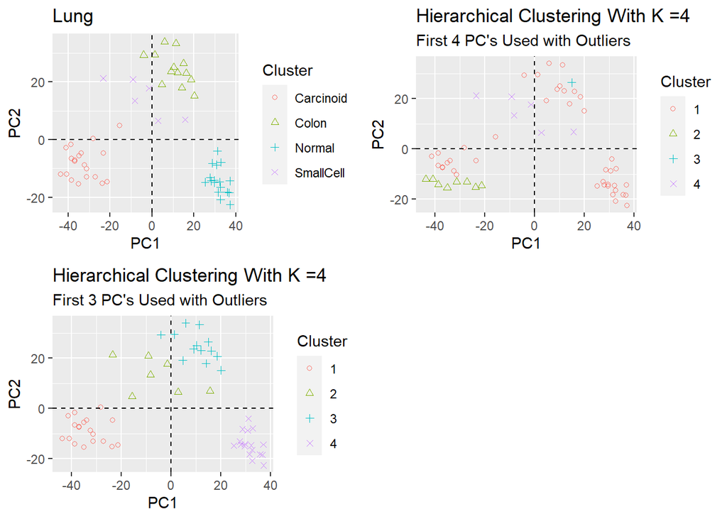

```r
pic3 <- Clusterplot(pcscore[,-c(1)],3,4,'Hierarchical Clustering')
pic4 <- Clusterplot(pcscore[,-c(1)],4,4,'Hierarchical Clustering')
multiplot(p.pcscore + labs(title="Lung" ,color = "Cluster", shape='Cluster'),
          pic3,pic4, cols=2)
```

## 1.3

Perform nominal logistics regression

```r
library(caret)
library(nnet)
```

```r
pcscore2 <- pcscore[,c(1:4)]
pcscore2$category <- as.factor(pcscore$category)
c1 <- multinom(category ~., data = pcscore2)
summary(c1)
```

```
## Call:
## multinom(formula = category ~ ., data = pcscore2)
##
## Coefficients:
##           (Intercept)      PC1        PC2         PC3
## Colon     -0.04380048 1.454861 2.51048617 -1.69416663
## Normal    -0.09410246 1.864607 0.03145686 -0.63788980
## SmallCell -1.64329766 1.642411 2.26104722  0.05950835
##
## Std. Errors:
##           (Intercept)      PC1      PC2      PC3
## Colon      20533.5456 819.8592 1803.441 2282.433
## Normal       211.3259 541.2358 3379.274 7708.383
## SmallCell  17892.0226 423.8778 1793.203 1985.411
##
## Residual Deviance: 0.0001360451
## AIC: 24.00014
```

```r
pred1 = predict(c1,data = pcscore2)
table(pcscore2$category, pred1)
```

```
##            pred1
##             Carcinoid Colon Normal SmallCell
##   Carcinoid        20     0      0         0
##   Colon             0    13      0         0
##   Normal            0     0     17         0
##   SmallCell         0     0      0         6
```

```r
mean(pred1 == pcscore2$category)
```

```
## [1] 1
```

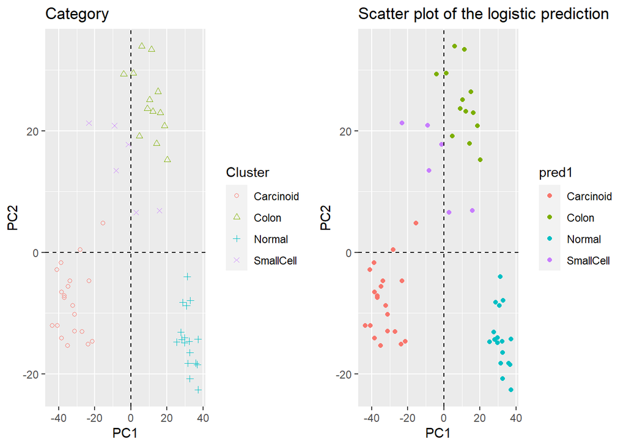

```r
pcscore3=cbind(pcscore2,pred1)
plot1 <- ggplot(data=pcscore3,aes(x=PC1,y=PC2,color=pred1)) +
  geom_point() +
  geom_hline(yintercept=0, linetype="dashed", color = "black") +
  geom_vline(xintercept=0, linetype="dashed", color = "black")+
  labs(title="Scatter plot of the logistic prediction")

multiplot(p.pcscore + labs(title="Category" ,color = "Cluster", shape='Cluster') +
            geom_hline(yintercept=0, linetype="dashed", color = "black") +
            geom_vline(xintercept=0, linetype="dashed", color = "black"),
          plot1, cols=2)
```

Logistics regression can separate the category in 100% accuracy.

perform LDA

```r
library(MASS)
library(dplyr)
lda1 <- lda(category ~., pcscore2)
lda1
```

```
## Call:
## lda(category ~ ., data = pcscore2)
##
## Prior probabilities of groups:
## Carcinoid     Colon    Normal SmallCell
## 0.3571429 0.2321429 0.3035714 0.1071429
##
## Group means:
##                  PC1        PC2       PC3
## Carcinoid -32.616012  -8.177295 -2.049265
## Colon      10.418386  24.636653 -9.598576
## Normal     31.780724 -14.320570  1.333451
## SmallCell  -3.898515  14.453184 23.849688
##
## Coefficients of linear discriminants:
##             LD1         LD2          LD3
## PC1  0.13011152  0.06529004 -0.002492116
## PC2  0.14407764 -0.15130974  0.024199884
## PC3 -0.04290663  0.06781950  0.120119904
##
## Proportion of trace:
##    LD1    LD2    LD3
## 0.6295 0.3264 0.0441
```

```r
pred2 = predict(lda1, pcscore2)
lda.class = pred2$class
table(lda.class, pcscore2$category)
```

```
##
## lda.class   Carcinoid Colon Normal SmallCell
##   Carcinoid        19     0      0         0
##   Colon             0    13      0         0
##   Normal            0     0     17         0
##   SmallCell         1     0      0         6
```

```r
mean(lda.class == pcscore2$category)
```

```
## [1] 0.9821429
```

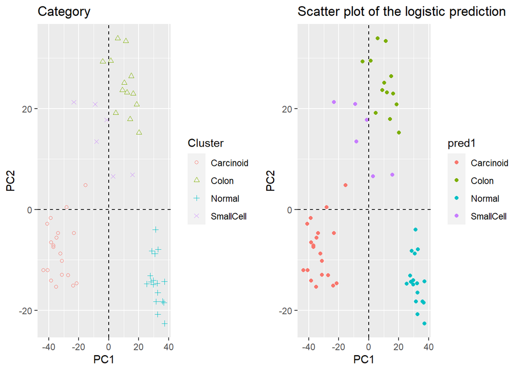

```r
pcscore4=cbind(pcscore2,pred1)
plot2 <- ggplot(data=pcscore4,aes(x=PC1,y=PC2,color=pred1)) +
  geom_point() +
  geom_hline(yintercept=0, linetype="dashed", color = "black") +
  geom_vline(xintercept=0, linetype="dashed", color = "black")+
  labs(title="Scatter plot of the logistic prediction")

multiplot(p.pcscore + labs(title="Category" ,color = "Cluster", shape='Cluster') +
            geom_hline(yintercept=0, linetype="dashed", color = "black") +
            geom_vline(xintercept=0, linetype="dashed", color = "black"),
          plot2, cols=2)
```

LDA can separate the category in 98.21% accuracy.